# Proyecto Bioinformática: Expresión Diferencial en DLBC (TCGA) y Análisis de SPN/CD43 con limma-voom

Pedro Daniel Pineda Martínez

# Introducción

El linfoma difuso de células B grandes (DLBCL) es la neoplasia linfoide agresiva más frecuente en adultos y se caracteriza por una marcada heterogeneidad biológica y clínica. Estudios de perfilamiento transcriptómico han demostrado que, aun dentro de una misma categoría histopatológica, existen programas de expresión génica distintos asociados con el estado de diferenciación de la célula tumoral, la proliferación y la respuesta del hospedero, los cuales impactan el pronóstico. En particular, la clasificación por “cell-of-origin” (p. ej., GCB vs ABC) y firmas transcriptómicas relacionadas con microambiente e inmunidad ayudan a explicar parte de la variación interpaciente y su relación con la supervivencia. [Alizadeh et al., 2000; Rosenwald et al., 2002; Chapuy et al., 2018].

En este documento se analiza expresión diferencial a partir de datos públicos de RNA-seq del consorcio TCGA, accesibles vía recount3, comparando pacientes *alive* vs *dead*. Además, se explora el comportamiento del gen **SPN** (que codifica CD43/sialoforina), dada la evidencia de que CD43 puede contribuir a fenotipos pro-tumorales en distintos contextos (adhesión, crecimiento y señalización) y, de manera relevante para DLBCL, su expresión inmunohistoquímica se ha asociado con peores desenlaces clínicos.

**Importancia de CD43 (SPN).** CD43 es una sialomucina transmembranal abundante en células hematopoyéticas, pero también se ha descrito su expresión/función en contextos tumorales y su potencial contribución a procesos como adhesión célula–mesotelio y crecimiento tumoral. En DLBCL, varios estudios reportan que CD43 positivo se asocia con menores tasas de respuesta completa y menor supervivencia global/event-free, y que coexpresión CD5/CD43 identifica subgrupos particularmente adversos.

# Objetivo

1. Identificar genes diferencialmente expresados entre *alive* vs *dead* en el proyecto **DLBC** (TCGA/recount3) usando **edgeR**.
2. Visualizar los resultados (volcán, MA, heatmap de genes más variables).
3. Evaluar **SPN/CD43**: distribución por estado vital, asociación con supervivencia (Kaplan–Meier) y su relación con la variación transcriptómica global.

# Métodos

### Descarga y construcción del RSE (DLBC)

```r
human_projects <- available_projects()

project_info <- subset(
  human_projects,
  project == "DLBC" &
    project_type == "data_sources" &
    project_home == "data_sources/tcga"
)

rse_DLBC <- create_rse(project_info)

assay(rse_DLBC, "counts") <- compute_read_counts(rse_DLBC)


cts <- assay(rse_DLBC, "counts")
cd <- as.data.frame(colData(rse_DLBC))
rd <- as.data.frame(rowData(rse_DLBC))

cat("Muestras iniciales:", ncol(cts), "\n")
```

```
## Muestras iniciales: 48
```

```r
cat("Genes iniciales:", nrow(cts), "\n")
```

```
## Genes iniciales: 63856
```

### Filtrado: vital_status + QC de conteos + filtro de genes

```r
## --- detectar columna de estado vital
vital_candidates <- grep(
  "vital|vital_status|deceased|dead|alive",
  names(cd),
  ignore.case = TRUE,
  value = TRUE
)

if (length(vital_candidates) == 0) {
  stop(
    "No se encontraron columnas tipo vital_status en colData(). Revisa names(cd)."
  )
}

# Elegir la columna más informativa (por defecto, la primera)
vital_col <- vital_candidates[1]
cat("Usando columna vital:", vital_col, "\n")
```

```
## Usando columna vital: tcga.gdc_cases.diagnoses.vital_status
```

```r
print(table(cd[[vital_col]], useNA = "ifany"))
```

```
##
## alive  dead
##    39     9
```

```r
## --- remover NA / unknown / not reported
bad_vital <- is.na(cd[[vital_col]]) |
  trimws(tolower(as.character(cd[[vital_col]]))) %in%
    c("", "na", "nan", "not reported", "unknown")

keep_vital <- !bad_vital

rse_vital <- rse_DLBC[, keep_vital]
cts_vital <- assay(rse_vital, "counts")
cd_vital <- as.data.frame(colData(rse_vital))

cat("Muestras tras filtrar vital:", ncol(cts_vital), "\n")
```

```
## Muestras tras filtrar vital: 48
```

```r
print(table(cd_vital[[vital_col]], useNA = "ifany"))
```

```
##
## alive  dead
##    39     9
```

```r
## --- QC por muestra
lib_size <- Matrix::colSums(cts_vital)
genes_det <- Matrix::colSums(cts_vital > 0)
zero_frac <- Matrix::colMeans(cts_vital == 0)

qc <- data.frame(
  sample = colnames(cts_vital),
  lib_size = as.numeric(lib_size),
  genes_detected = as.numeric(genes_det),
  zero_fraction = as.numeric(zero_frac)
)

summary(qc)
```

```
##     sample             lib_size        genes_detected  zero_fraction
##  Length:48          Min.   :29940729   Min.   :27850   Min.   :0.1795
##  Class :character   1st Qu.:48665229   1st Qu.:32126   1st Qu.:0.4672
##  Mode  :character   Median :51934062   Median :33368   Median :0.4775
##                     Mean   :53950435   Mean   :33391   Mean   :0.4771
##                     3rd Qu.:62763786   3rd Qu.:34023   3rd Qu.:0.4969
##                     Max.   :78008165   Max.   :52392   Max.   :0.5639
```

```r
min_lib <- 5e6
min_genes <- 10000
max_zeros <- 0.85

keep_qc <- with(
  qc,
  lib_size >= min_lib & genes_detected >= min_genes & zero_fraction <= max_zeros
)
cat("Muestras que pasan QC:", sum(keep_qc), "de", length(keep_qc), "\n")
```

```
## Muestras que pasan QC: 48 de 48
```

```r
rse_qc <- rse_vital[, keep_qc]
cts_qc <- assay(rse_qc, "counts")

## --- filtro de genes (>=10 counts en >=10% de muestras)
n <- ncol(cts_qc)
keep_gene <- Matrix::rowSums(cts_qc >= 10) >= ceiling(0.10 * n)

rse_filt <- rse_qc[keep_gene, ]
cts_final <- assay(rse_filt, "counts")
coldata_final <- as.data.frame(colData(rse_filt))
rowdata_final <- as.data.frame(rowData(rse_filt))

cat("Genes finales:", nrow(cts_final), "\n")
```

```
## Genes finales: 27495
```

```r
cat("Muestras finales:", ncol(cts_final), "\n")
```

```
## Muestras finales: 48
```

# Resultados

### Expresión diferencial Alive vs Dead con limma-voom (edgeR)

```r
v <- tolower(trimws(as.character(coldata_final[[vital_col]])))

group <- ifelse(
  v %in% c("alive", "living"),
  "alive",
  ifelse(v %in% c("dead", "deceased"), "dead", NA)
)

keep_ad <- !is.na(group)
cts_ad <- cts_final[, keep_ad]
cd_ad <- coldata_final[keep_ad, , drop = FALSE]
group <- factor(group[keep_ad], levels = c("alive", "dead"))

cat("Tabla alive/dead:\n")
```

```
## Tabla alive/dead:
```

```r
print(table(group))
```

```
## group
## alive  dead
##    39     9
```

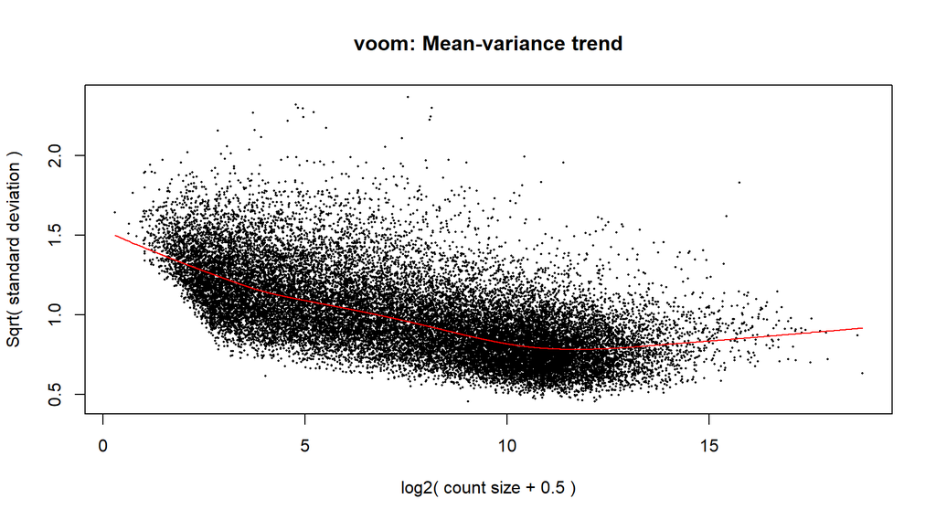

```r
y <- DGEList(counts = cts_ad, group = group)
keep_gene2 <- filterByExpr(y, group = group)
y <- y[keep_gene2, , keep.lib.sizes = FALSE]
y <- calcNormFactors(y, method = "TMM")

design <- model.matrix(~ 0 + group)
colnames(design) <- levels(group)

v <- voom(y, design, plot = TRUE)
```

```r
fit <- lmFit(v, design)


# contraste: dead vs alive (logFC>0 => más alto en dead)
contr <- makeContrasts(DeadVsAlive = dead - alive, levels = design)
fit.contr <- contrasts.fit(fit, contr)

fit.eb <- eBayes(fit.contr)
res <- topTable(fit.eb, coef = "DeadVsAlive", number = Inf, sort.by = "P")

## --- anotar símbolo si existe
gene_col_candidates <- intersect(
  c("gene_name", "gene", "symbol", "external_gene_name"),
  colnames(rowdata_final)
)
gene_col <- if (length(gene_col_candidates) > 0) {
  gene_col_candidates[1]
} else {
  NULL
}

res$gene <- if (!is.null(gene_col)) {
  rowdata_final[[gene_col]][match(rownames(res), rownames(rowdata_final))]
} else {
  NA_character_
}

head(res, 20)
```

```
##                        logFC    AveExpr        t      P.Value adj.P.Val         B          gene
## ENSG00000171540.7  3.4583200 -3.9406573 4.944285 8.896700e-06 0.2266701 -4.158671           OTP
## ENSG00000077327.15 2.2577264 -3.0423659 4.372231 6.175791e-05 0.5764418 -4.193183         SPAG6
## ENSG00000230561.4  1.2387508 -1.0037987 4.343710 6.787524e-05 0.5764418 -4.053330       CCDC192
## ENSG00000232815.1  1.4353415  0.9499543 4.071523 1.651644e-04 0.9999841 -3.872560       DUX4L50
## ENSG00000053108.16 2.1265452 -3.7882963 3.896885 2.885827e-04 0.9999841 -4.320489         FSTL4
## ENSG00000229191.1  2.3934101 -3.2694239 3.791740 4.017367e-04 0.9999841 -4.291781 RP11-168O16.1
## ENSG00000187510.8  2.2602849  0.1901132 3.750433 4.569827e-04 0.9999841 -4.002297       PLEKHG7
## ENSG00000118990.5  2.3608851 -4.0115167 3.705685 5.250503e-04 0.9999841 -4.346814        GLRXP3
## ENSG00000173947.13 1.4526285 -0.8545317 3.657007 6.101206e-04 0.9999841 -4.172248          PIFO
## ENSG00000185033.14 0.7800359  4.1475866 3.608273 7.084311e-04 0.9999841 -3.561930        SEMA4B
## ENSG00000139626.15 1.1078673  5.2922426 3.545323 8.580030e-04 0.9999841 -3.499612         ITGB7
## ENSG00000101213.6  1.3205685  0.5283647 3.514716 9.411946e-04 0.9999841 -4.093018          PTK6
## ENSG00000204186.7  1.5511580  1.4853435 3.460047 1.109282e-03 0.9999841 -3.974717         ZDBF2
## ENSG00000117586.10 1.3148987  2.8938742 3.354784 1.516591e-03 0.9999841 -3.824417        TNFSF4
## ENSG00000163171.7  0.8129633  4.5642867 3.331158 1.625778e-03 0.9999841 -3.659406      CDC42EP3
## ENSG00000259577.1  0.9360745 -0.5043713 3.319497 1.682376e-03 0.9999841 -4.234996        CERNA1
## ENSG00000180178.10 2.7710252 -2.9280305 3.300930 1.776363e-03 0.9999841 -4.331952        FAR2P1
## ENSG00000139651.10 0.6349061  5.9629804 3.248136 2.071501e-03 0.9999841 -3.662228        ZNF740
## ENSG00000182742.5  0.8428483  2.0026929 3.212478 2.296428e-03 0.9999841 -4.043034         HOXB4
## ENSG00000134070.4  1.2171477  2.5353685 3.202750 2.361686e-03 0.9999841 -3.950874         IRAK2
```

##### Volcano Plot

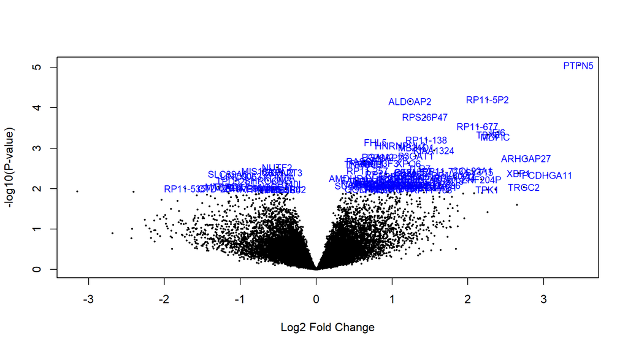

```r
volcanoplot(
  fit.eb,
  coef = "DeadVsAlive",
  highlight = 100,
  names = res$gene,
)
```

```r
A <- res$AveExpr
M <- res$logFC
```

##### MA Plot

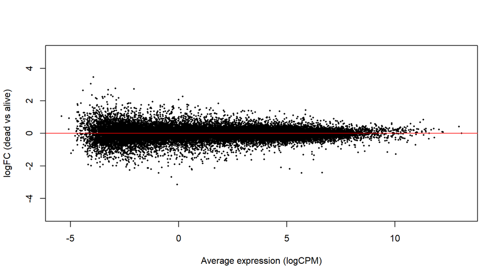

```r
plot(
  A,
  M,
  pch = 16,
  cex = 0.45,
  xlab = "Average expression (logCPM)",
  ylab = "logFC (dead vs alive)",
  ylim = c(-5, 5)
)
abline(h = 0, col = "red")
```

##### Heatmap

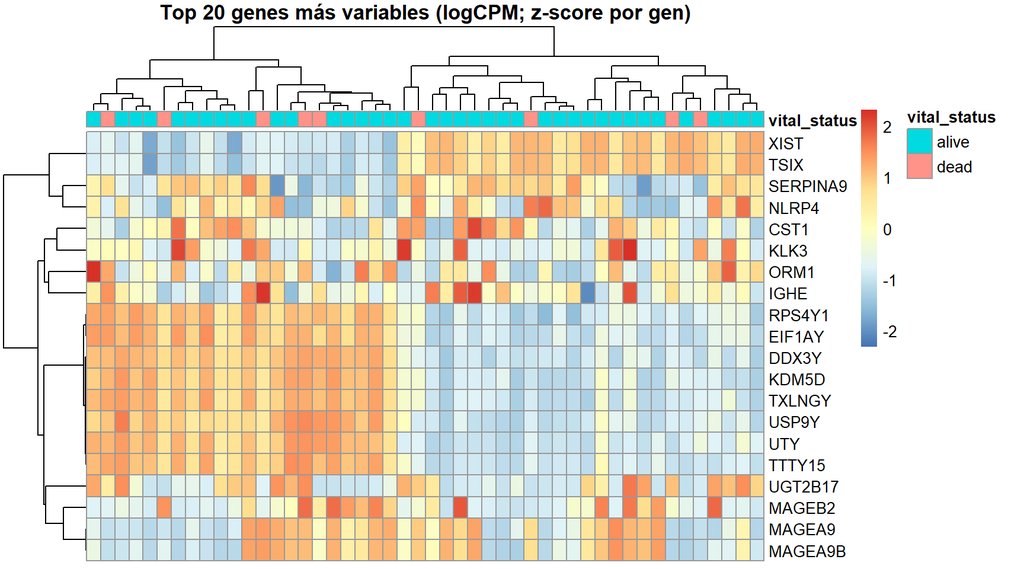

```r
logcpm <- v$E

top_n <- 20
vars <- matrixStats::rowVars(logcpm)
top_idx <- order(vars, decreasing = TRUE)[seq_len(min(top_n, nrow(logcpm)))]
mat <- logcpm[top_idx, , drop = FALSE]

## renombrar filas con símbolo si existe
if (!is.null(gene_col)) {
  labs <- rowdata_final[[gene_col]][match(
    rownames(mat),
    rownames(rowdata_final)
  )]
  labs[is.na(labs) | labs == ""] <- rownames(mat)[is.na(labs) | labs == ""]
  rownames(mat) <- make.unique(labs)
}

## anotar columnas
ann_col <- data.frame(vital_status = group)
rownames(ann_col) <- colnames(mat)

## ordenar por grupo
ord <- order(group)
mat <- mat[, ord, drop = FALSE]
ann_col <- ann_col[ord, , drop = FALSE]

pheatmap(
  mat,
  scale = "row",
  show_colnames = FALSE,
  annotation_col = ann_col,
  clustering_distance_rows = "correlation",
  clustering_distance_cols = "correlation",
  main = paste0(
    "Top ",
    top_n,
    " genes más variables (logCPM; z-score por gen)"
  ),
)
```

### SPN (CD43): distribución, supervivencia y relación con transcriptoma global

##### Violin plot SPN vs estado vital

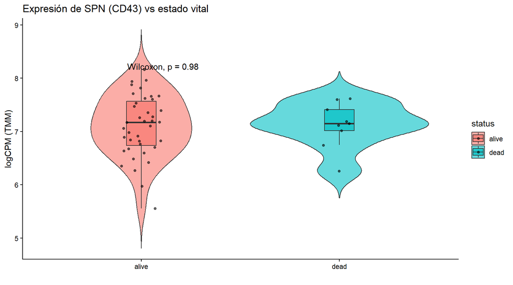

```r
## localizar SPN por símbolo
if (is.null(gene_col)) {
  stop("No hay columna de símbolo en rowData para ubicar SPN.")
}

spn_row <- which(rowdata_final[[gene_col]] == "SPN")
if (length(spn_row) == 0) {
  stop("SPN no encontrado en rowData (símbolos).")
}

SPN_expr <- as.numeric(logcpm[spn_row, ])

df_spn <- data.frame(
  status = group,
  expr = SPN_expr
)
df_spn <- df_spn[!is.na(df_spn$status), ]

violinplt <- ggplot(df_spn, aes(status, expr, fill = status)) +
  geom_violin(trim = FALSE, alpha = 0.6) +
  geom_boxplot(width = 0.15, outlier.shape = NA, alpha = 0.7) +
  geom_jitter(width = 0.10, alpha = 0.6, size = 1.2) +
  stat_compare_means(method = "wilcox.test") +
  theme_classic() +
  labs(
    title = "Expresión de SPN (CD43) vs estado vital",
    y = "logCPM (TMM)",
    x = ""
  )

print(violinplt)
```

##### Supervivencia (Kaplan–Meier) por SPN High vs Low

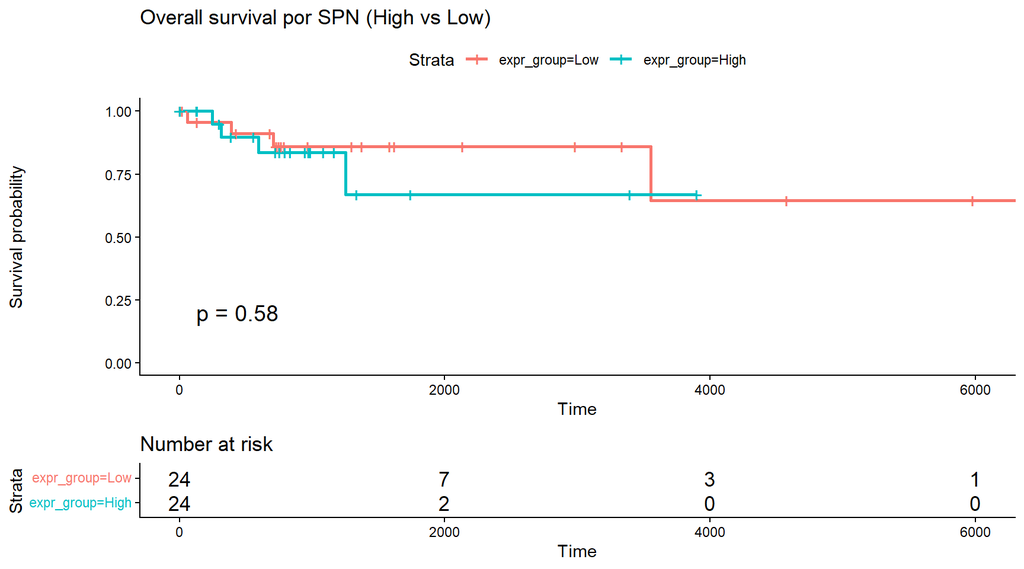

```r
d_death <- suppressWarnings(as.numeric(as.character(
  coldata_final$tcga.gdc_cases.diagnoses.days_to_death
)))
d_fu <- suppressWarnings(as.numeric(as.character(
  coldata_final$tcga.gdc_cases.diagnoses.days_to_last_follow_up
)))

time <- ifelse(!is.na(d_death), d_death, d_fu)
event <- ifelse(group == "dead", 1, 0)

expr_group <- ifelse(SPN_expr > median(SPN_expr, na.rm = TRUE), "High", "Low")
expr_group <- factor(expr_group, levels = c("Low", "High"))

surv_df <- data.frame(
  time = as.numeric(time),
  event = as.integer(event),
  expr_group = expr_group
)

surv_df <- surv_df[complete.cases(surv_df), ]
surv_df <- surv_df[surv_df$time >= 0, ]

fit <- survfit(Surv(time, event) ~ expr_group, data = surv_df)

surv_plot <- ggsurvplot(
  fit,
  data = surv_df,
  pval = TRUE,
  risk.table = TRUE,
  conf.int = FALSE,
  ggtheme = theme_classic(),
  title = "Overall survival por SPN (High vs Low)"
)

print(surv_plot)
```

##### SPN vs transcriptome variation

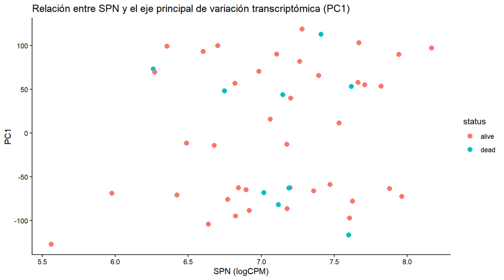

```r
pca <- prcomp(t(logcpm), scale. = TRUE)

df_pc <- data.frame(
  PC1 = pca$x[, 1],
  PC2 = pca$x[, 2],
  SPN = SPN_expr,
  status = group
)

ggplot(df_pc, aes(SPN, PC1, color = status)) +
  geom_point(size = 2.7) +
  theme_classic() +
  labs(
    title = "Relación entre SPN y el eje principal de variación transcriptómica (PC1)",
    x = "SPN (logCPM)",
    y = "PC1"
  )
```

# Discusión y conclusión

Los genes de mayor variabilidad en DLBCL suelen agruparse en categorías biológicamente esperables:

Genes ligados a sexo (p. ej., XIST/TSIX y genes del cromosoma Y como RPS4Y1, EIF1AY, UTY, DDX3Y, KDM5D), que reflejan una fuente fuerte de variación inter-individuo no necesariamente tumoral.

Genes de inmunoglobulinas/BCR (p. ej., segmentos IGHV/IGKV/IGLV o genes asociados a plasmablastos), que capturan heterogeneidad de la identidad B, estado de activación y/o composición tumoral–microambiente.

Antígenos de cancer testicular o programas de proliferación/estrés, que pueden emerger en subgrupos específicos y son consistentes con la heterogeneidad molecular descrita en DLBCL por estudios de perfilamiento transcriptómico y genómico. En conjunto, este patrón concuerda con que DLBCL no es una entidad homogénea, sino un espectro de estados biológicos con consecuencias pronósticas.